# a3_task3_gabrielle_barsotti

Gabrielle Barsotti

11/7/2020

## Summary

- In this document I will be exploring the difference between purple and red sea urchins located off the Santa Barbara Coast. The data was taken from red and purple sea urchins at 5 different locations.

## Read in the Urchin Data

```r
urchin_data <- read_csv(here("data", "urchins.csv")) %>%
  clean_names()
```

## Exploring data visulization

- Using the data to compare the sizes between purple and red sea urchins
- Only need to do minimal updates to the data tables

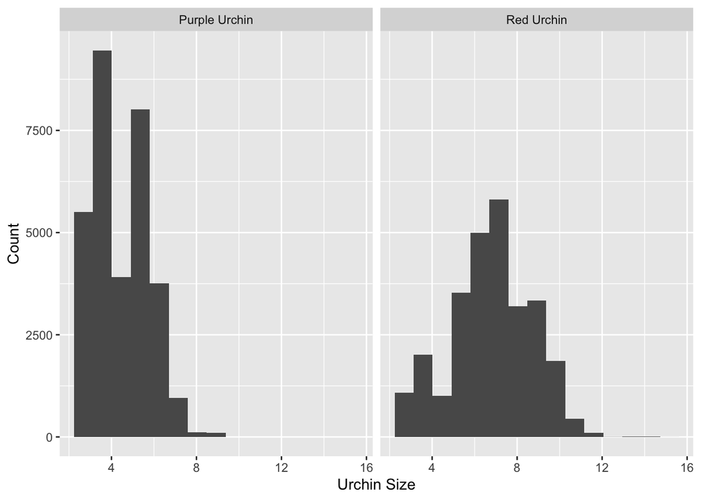

```r
ggplot(data = urchin_data, aes(x = size)) +
  geom_histogram(bins = 15) +
  facet_wrap(~common_name) +
  labs(x = "Urchin Size",
       y = "Count")
```

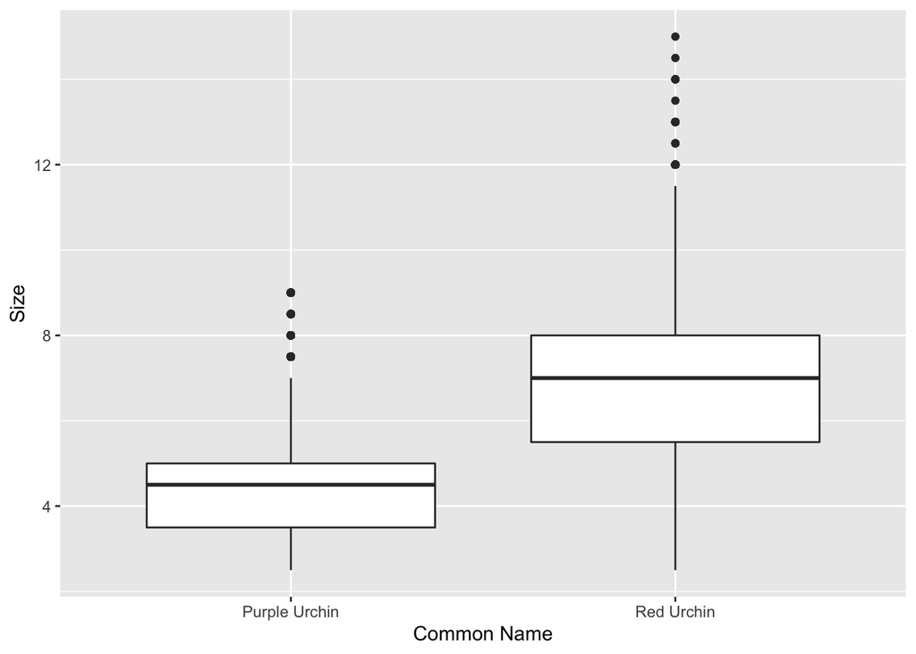

```r
ggplot(data = urchin_data, aes(x = common_name, y = size)) +
  geom_boxplot() +
  labs(x = "Common Name",
       y = "Size")
```

### Summary Table & Descriptive Statistics

- This summary table will look at the mean, median and standard diviation of both purple and red sea urchins

```r
urchin_stats <- urchin_data %>%
  group_by(common_name) %>%
  summarize(mean = mean(size),
            median = median(size),
            sd = sd(size),
            sample_size = n())

  kbl(urchin_stats) %>%
    kable_styling()
```

| common_name | mean | median | sd | sample_size |
| --- | --- | --- | --- | --- |
| Purple Urchin | 4.469797 | 4.5 | 1.175264 | 31805 |
| Red Urchin | 6.776489 | 7.0 | 1.891343 | 27408 |

### Calculation for difference in mean

```r
6.776489 - 4.469797
```

```
## [1] 2.306692
```

### Calculation for percent difference

```r
(6.776489 - 4.469797) / ((4.469797 + 6.776489) / 2) *100
```

```
## [1] 41.0214
```

## Section 2 : Exploring purple urchin count by site and year

```r
urchin_clean_dates <- urchin_data %>%
  mutate(date = mdy(date))

class(urchin_clean_dates$date)
```

```
## [1] "Date"
```

```r
purple_urchin <- urchin_clean_dates %>%
  filter(common_name == "Purple Urchin") %>%
  mutate(date = ymd(date)) %>%
  mutate(year = year(date)) %>%
  mutate(site_full = recode(site, "NAPL" = "Naples Reef", "AQUE" = "Arroyo Quemado Reef", "CARP" = "Carpinteria Reef",
                            "MOHK" = "Mohawk Reef", "IVEE" = "Isla Vista Reef"))
```

```r
purple_urchin_total <- purple_urchin %>%
  select("site_full", "year") %>%
  group_by(site_full, year) %>%
  count(site_full)
```

### Made an exploritory graph

- This graph shows the counts of purple urchins recorded at each site over time for years included in the summary table

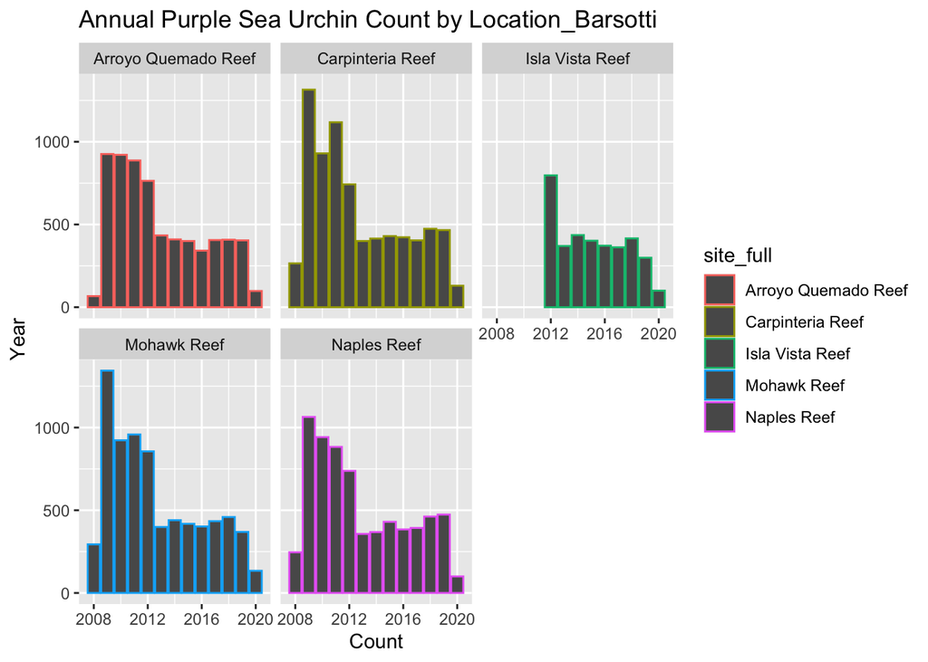

```r
ggplot(data = purple_urchin_total, aes(x = year, y = n)) +
  geom_col(aes(color = site_full)) +
  facet_wrap(~site_full) +
  labs(x = "Count",
       y = "Year",
       title = "Annual Purple Sea Urchin Count by Location_Barsotti")
```